# Part II - (Insights from Airline On-Time Performance Data)

## by (Jane Harry)

## Investigation Overview

In this investigation, I wanted to look at the characteristics of flights that experienced delays. The main focus was on the month of the year, the airline carrier, and the types of delays. For this presentation, I start by introducing the Unique Carriers, and then present the Carriers responsible for Delays. Next, I present the pattern of delays on a monthly basis, and finally, I explore the various reasons for delay on a monthly basis. The bar charts are grouped by months, and the type of delay is color-coded, while the line graph depicting reasons for delay is color-coded on the delays.

```python
## Dataset Overview

> This dataset reports flights in the United States, including carriers, arrival and departure delays, and reasons for delays, for the year 2007.
```

## (Visualization 1)

> Through this plot, I examine the distribution of Unique Carriers in the dataset

```
Text(0.5,1,'Distribution of Unique Carriers in 2007')
```

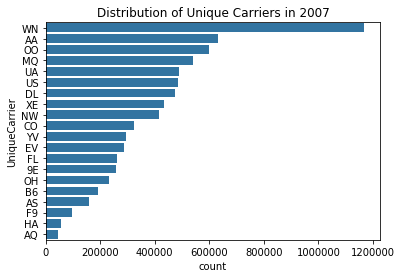

```python
# plotting the distribution of carriers
base_color = sb.color_palette()[0]
carrier_order=df['UniqueCarrier'].value_counts().index
sb.countplot(data=df, y='UniqueCarrier', color=base_color, order=carrier_order);
plt.title('Distribution of Unique Carriers in 2007')
```

## (Visualization 2)

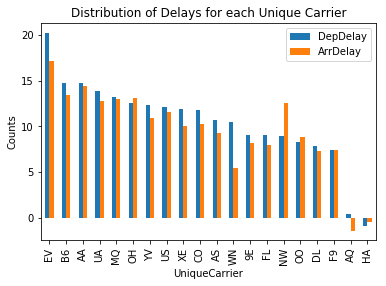

```python
# https://shawnemhe.github.io/udacity-data-analyst/p6/python_eda/python_eda.html
# I grouped by airlines, and got the average departure and arrival delays
df.groupby('UniqueCarrier').agg({'DepDelay':'mean', 'ArrDelay':'mean'}).sort_values('DepDelay', ascending=False).plot.bar()
plt.ylabel('Counts')
plt.title('Distribution of Delays for each Unique Carrier')
plt.show()
```

## (Visualization 3)

> There are flight delays in different months of the year due to ceratin conditions such as weather, etc

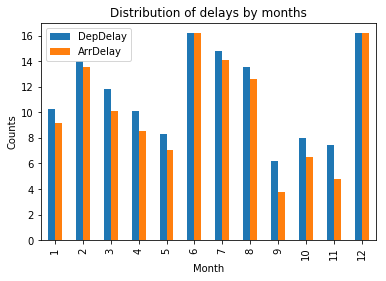

```python
# https://shawnemhe.github.io/udacity-data-analyst/p6/python_eda/python_eda.html
# I grouped the dataset by month, and got the average departure delay, and arrival delay
df.groupby('Month').agg({'DepDelay':'mean', 'ArrDelay':'mean'}).plot.bar()
plt.ylabel('Counts')
plt.title('Distribution of delays by months')
plt.show()
```

## (Visualization 4)

There are different monthly distributions of 'CarrierDelay','WeatherDelay','NASDelay','SecurityDelay','LateAircraftDelay' as reasons for delays

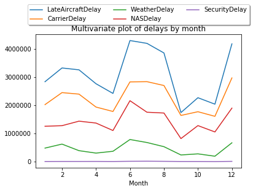

```python
# ref: https://www.kaggle.com/code/adveros/flight-delay-eda-exploratory-data-analysis/notebook
delayed_df = delayed_flights.filter(['Month','CarrierDelay','WeatherDelay','NASDelay','SecurityDelay','LateAircraftDelay'], axis=1)
delayed_df = delayed_df.groupby('Month')['LateAircraftDelay','CarrierDelay','WeatherDelay','NASDelay','SecurityDelay'].sum().plot()
delayed_df.legend(loc='upper center', bbox_to_anchor=(0.5, 1.25), ncol=3, fancybox=True, shadow=True)
plt.title('Multivariate plot of delays by month')
plt.show()
```